# Regression, GLMs, and Bayesian vs Frequentist perspectives

## Count regression

The regression model above works reasonably well, but it doesn't account for the fact that the variable we're predicting is a whole number (meaning that it takes values $0, 1, 2, 3, \ldots$). When we say that $y|\beta \sim N(X\beta, \sigma^2 I)$, and using log-transformed data for $y$, we're implicitly saying that $y$ can never be 0. Can we use a different likelihood that is designed specifically for this kind of data?

We've already seen one different model for the case where $y$ is binary: logistic regression. In this section, we'll explore two models for predicting count data: Poisson regression and negative binomial regression.

### Poisson regression

Recall that the [Poisson distribution](https://en.wikipedia.org/wiki/Poisson_distribution) is a distribution over counts and count-like values. It has one *positive* parameter $\lambda$ that represents its mean (and variance, too).

In Poisson regression, we're going to assume a Poisson likelihood for each $y_i$. The parameter of the distribution must be positive, but $x_i^T\beta$ could be negative. There are several ways to make the possibly-negative value into a positive one, but we'll use $\exp(x_i^T \beta)$ as the mean. This way, we don't have to log-transform the data. We can write out our likelihood:

$$ y_i | \beta \sim \text{Poisson}(\exp(x_i^T \beta)) $$

Let's try it out in PyMC3! Even though the different likelihood means that we're optimizing a completely different loss function, we only need to make a few tiny changes to our code from earlier:

```python
# Not counting variable name changes, there are two differences
# between this cell and the version we did before: can you find them?
with pm.Model() as poisson_model:
    glm.GLM.from_formula('totals ~ year', ok_turbines, family=glm.families.Poisson())
    # draw posterior samples using NUTS sampling
    poisson_trace = pm.sample(1000, cores=2, target_accept=0.95, return_inferencedata=True)
```

```
Auto-assigning NUTS sampler...
Initializing NUTS using jitter+adapt_diag...
Multiprocess sampling (2 chains in 2 jobs)
NUTS: [mu, year, Intercept]
```

100.00% [4000/4000 00:31<00:00 Sampling 2 chains, 0 divergences]

One consequence of the Poisson likelihood is that $E[y|\beta] = exp(x_i^T \beta)$, which means that our interpretation of the coefficient(s) is the same as it was in the earlier case.

```python
poisson_trace
```

arviz.InferenceData

- posterior

  ```
  <xarray.Dataset>
  Dimensions:    (chain: 2, draw: 1000)
  Coordinates:
    * chain      (chain) int64 0 1
    * draw       (draw) int64 0 1 2 3 4 5 6 7 ... 992 993 994 995 996 997 998 999
  Data variables:
      Intercept  (chain, draw) float64 4.886 4.886 4.894 ... 4.918 5.005 4.993
      year       (chain, draw) float64 0.1877 0.1876 0.1874 ... 0.1807 0.1816
      mu         (chain, draw) float64 9.637 10.6 9.677 ... 29.19 2.696 14.69
  Attributes:
      created_at:                 2021-02-17T20:51:30.415535
      arviz_version:              0.11.1
      inference_library:          pymc3
      inference_library_version:  3.11.0
      sampling_time:              31.462523221969604
      tuning_steps:               1000
  ```

- log_likelihood

  ```
  <xarray.Dataset>
  Dimensions:  (chain: 2, draw: 1000, y_dim_0: 17)
  Coordinates:
    * chain    (chain) int64 0 1
    * draw     (draw) int64 0 1 2 3 4 5 6 7 8 ... 992 993 994 995 996 997 998 999
    * y_dim_0  (y_dim_0) int64 0 1 2 3 4 5 6 7 8 9 10 11 12 13 14 15 16
  Data variables:
      y        (chain, draw, y_dim_0) float64 -154.6 -40.52 ... -49.02 -123.7
  Attributes:
      created_at:                 2021-02-17T20:51:30.620348
      arviz_version:              0.11.1
      inference_library:          pymc3
      inference_library_version:  3.11.0
  ```

- sample_stats

- observed_data

  ```
  <xarray.Dataset>
  Dimensions:  (y_dim_0: 17)
  Coordinates:
    * y_dim_0  (y_dim_0) int64 0 1 2 3 4 5 6 7 8 9 10 11 12 13 14 15 16
  Data variables:
      y        (y_dim_0) float64 1.0 114.0 296.0 ... 3.989e+03 4.022e+03 4.462e+03
  Attributes:
      created_at:                 2021-02-17T20:51:30.621926
      arviz_version:              0.11.1
      inference_library:          pymc3
      inference_library_version:  3.11.0
  ```

```
array([[<AxesSubplot:title={'center':'Intercept'}>,
        <AxesSubplot:title={'center':'Intercept'}>],
       [<AxesSubplot:title={'center':'year'}>,
        <AxesSubplot:title={'center':'year'}>],
       [<AxesSubplot:title={'center':'mu'}>,
        <AxesSubplot:title={'center':'mu'}>]], dtype=object)
```

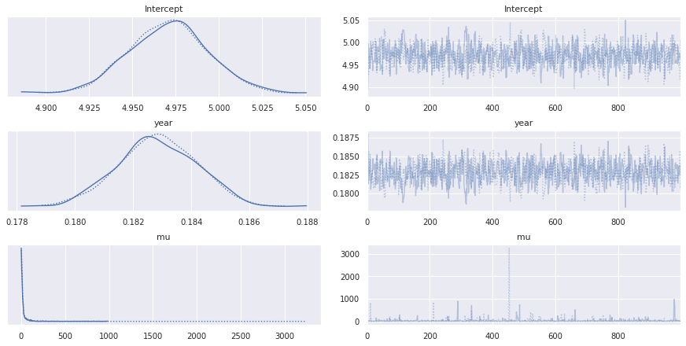

```python
arviz.plot_trace(poisson_trace)
```

```python
np.exp(0.203)
```

```
1.2250724682474992
```

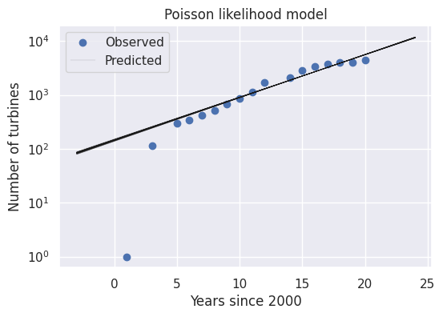

```python
show_posterior_predictive(poisson_trace, title="Poisson likelihood model")
```

From this plot, we can see that all of the gray lines look almost exactly the same! Why is this happening? Let's think about the implicit assumptions we're making when choosing a Poisson likelihood. The Poisson distribution's mean is equal to its variance. So, when we use a Poisson distribution for $y$, we're implicitly assuming that $E[y]$ and $\text{var}(y)$ are reasonably close together. Does this assumption hold up?

```python
print("Mean:    ", np.mean(ok_turbines.totals))
print("Variance:", np.var(ok_turbines.totals))
```

```
Mean:     1793.7058823529412
Variance: 2399097.9723183387
```

Clearly, the Poisson is a poor choice for fitting this data! When the model assumes a lower variance than is actually present in the data, we say that the data are **overdispersed** (i.e., that they're too spread out relative to the model's assumptions). We should choose a different distribution that gives us the ability to control the variance as well as the mean.

(Note that this wasn't a problem with the normal likelihood earlier: because the normal distribution has two separate parameters for mean and variance, we can choose them separately to reflect the fact that the variance may be higher than the mean.)

### Negative binomial regression

The [negative binomial distribution](https://en.wikipedia.org/wiki/Negative_binomial_distribution) is also a distribution over counts, but it's more sophisticated than the Poisson distribution. We can think of it one of two ways:

- It's the sum of $r$ [Geometric random variables], each with parameter $p$ (success probability).
- It's like a Poisson distribution if the mean parameter ($\lambda$ above) were also random.

There are several different ways to parametrize the negative binomial. How do we choose which one to use? There are two answers:

1. We want a parametrization that lets us choose the mean, since we want the mean value for $y_i$ to be $\exp(x_i^T \beta)$.
2. Since we're using PyMC3, we're limited to whichever parametrization(s) it supports.

Even though the form of the distribution is significantly more complex and manipulating it involves more work, using it in our regression model requires only a tiny change to what we were doing before:

```python
# Not counting variable name changes, there's only one difference
# between this cell and the Poisson regression code: can you find it?

with pm.Model() as negbin_model:
    glm.GLM.from_formula('totals ~ year', ok_turbines, family=glm.families.NegativeBinomial())
    # draw posterior samples using NUTS sampling
    negbin_trace = pm.sample(1000, cores=2, target_accept=0.95, return_inferencedata=True)
```

```
Auto-assigning NUTS sampler...
Initializing NUTS using jitter+adapt_diag...
Multiprocess sampling (2 chains in 2 jobs)
NUTS: [alpha, mu, year, Intercept]
```

100.00% [4000/4000 00:09<00:00 Sampling 2 chains, 0 divergences]

```
Sampling 2 chains for 1_000 tune and 1_000 draw iterations (2_000 + 2_000 draws total) took 10 seconds.
```

```
array([[<AxesSubplot:title={'center':'Intercept'}>,
        <AxesSubplot:title={'center':'Intercept'}>],
       [<AxesSubplot:title={'center':'year'}>,
        <AxesSubplot:title={'center':'year'}>],
       [<AxesSubplot:title={'center':'mu'}>,
        <AxesSubplot:title={'center':'mu'}>],
       [<AxesSubplot:title={'center':'alpha'}>,
        <AxesSubplot:title={'center':'alpha'}>]], dtype=object)
```

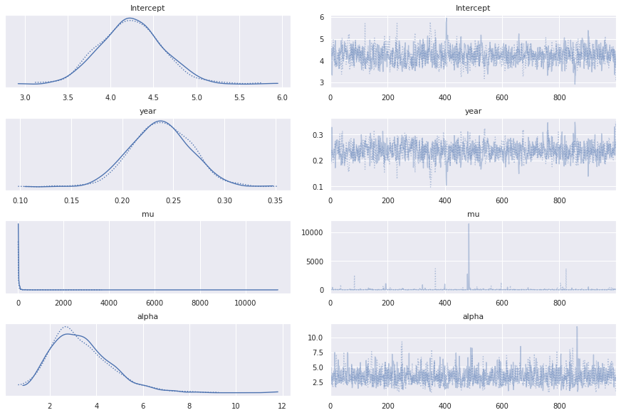

```python
arviz.plot_trace(negbin_trace)
```

```python
np.exp(0.26)
```

```
1.2969300866657718
```

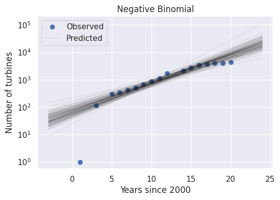

```python
show_posterior_predictive(negbin_trace, title="Negative Binomial")
```

These look much better than either of the previous two: we're more robust to the outlier value in 2001, but the posterior properly captures uncertainty in the prediction.

### What happened to the priors?

You may have noticed that I claimed we're doing "Bayesian inference", but there were no priors used above! By default, PyMC3 uses a "flat" prior, which is uniform over all real numbers. This is what's called an "improper" prior, because it doesn't and can't integrate to 1 (or to any finite number).

You can specify priors for $\beta$: can you find out how using the documentation?

## Generalized Linear Models

By now, you've seen four different versions of regression in the Bayesian setting:

- Linear regression, for predicting real-valued outputs
- Logistic regression, for predicting binary outputs (classification)
- Poisson regression, for predicting counts
- Negative binomial regression, for predicting counts

Let's review what they had in common and what was different between them:

1. For all four, computing our prediction for $y_i$ begins with computing $x_i^T \beta$. This part is a *linear* function of $x_i$, even if we do something nonlinear with it later.
2. Each one had a different function that we used to compute the average value of $y_i$ from $x_i^T \beta$. Since this function links the linearly transformed input $x$ to the output $y$, you might expect us to call it the **link function**: this would make a lot of sense. However, the convention is to do the opposite, and call it the **inverse link function**. As you might expect from this name, the **link function** is the inverse of the inverse link function.
3. For each one, we used a different distribution for the likelihood. In all cases, the output of the function above was always the mean of this distribution.

The following table summarizes the different choices of likelihood and link function for the four versions that we've seen:

| Regression | Inverse link function | Link function | Likelihood | | :-- | :-- | :-- | :-- | | Linear | identity | identity | Gaussian | | Logistic | sigmoid | [logit](https://en.wikipedia.org/wiki/Logit) | Bernoulli | | Poisson | exponential | log | Poisson | | Negative binomial | exponential | log | Negative binomial |

These ideas form the basis for what are known as Generalized Linear Models, or GLMs. Once we choose a link function and a likelihood distribution, our model is fully specified, and we can approximate the posterior distribution over the coefficients in $\beta$.

### Frequentist GLMs

We'll look at the same models we implemented before, but this time we'll use the `statsmodels` package to look at things through a frequentist lens.

```python
gaussian_model = sm.GLM(
    np.log(ok_turbines.totals), ok_turbines.year,
    family=sm.families.Gaussian()
)
gaussian_results = gaussian_model.fit()
print(gaussian_results.summary())
```

```
                 Generalized Linear Model Regression Results
==============================================================================
Dep. Variable:                 totals   No. Observations:                   17
Model:                            GLM   Df Residuals:                       16
Model Family:                Gaussian   Df Model:                            0
Link Function:               identity   Scale:                          3.3610
Method:                          IRLS   Log-Likelihood:                -33.911
Date:                Wed, 17 Feb 2021   Deviance:                       53.776
Time:                        12:51:50   Pearson chi2:                     53.8
No. Iterations:                     3
Covariance Type:            nonrobust
==============================================================================
                 coef    std err          z      P>|z|      [0.025      0.975]
------------------------------------------------------------------------------
year           0.5346      0.035     15.098      0.000       0.465       0.604
==============================================================================
```

This model's results don't look like the others, because it's missing an intercept. We need to use the `add_constant` function in `statsmodels`:

```python
gaussian_model_intercept = sm.GLM(
    np.log(ok_turbines.totals), sm.add_constant(ok_turbines.year),
    family=sm.families.Gaussian()
)
gaussian_results = gaussian_model_intercept.fit()
print(gaussian_results.summary())
```

```
                 Generalized Linear Model Regression Results
==============================================================================
Dep. Variable:                 totals   No. Observations:                   17
Model:                            GLM   Df Residuals:                       15
Model Family:                Gaussian   Df Model:                            1
Link Function:               identity   Scale:                          1.1810
Method:                          IRLS   Log-Likelihood:                -24.472
Date:                Wed, 17 Feb 2021   Deviance:                       17.716
Time:                        12:51:50   Pearson chi2:                     17.7
No. Iterations:                     3
Covariance Type:            nonrobust
==============================================================================
                 coef    std err          z      P>|z|      [0.025      0.975]
------------------------------------------------------------------------------
const          3.2602      0.590      5.526      0.000       2.104       4.417
year           0.3023      0.047      6.435      0.000       0.210       0.394
==============================================================================
```

Take a minute to look over the results. What does it mean that the standard error for the estimated `year` coefficient is 0.047?

```python
poisson_model = sm.GLM(
    ok_turbines.totals, sm.add_constant(ok_turbines.year),
    family=sm.families.Poisson()
)
poisson_results = poisson_model.fit()
print(poisson_results.summary())
```

```
                 Generalized Linear Model Regression Results
==============================================================================
Dep. Variable:                 totals   No. Observations:                   17
Model:                            GLM   Df Residuals:                       15
Model Family:                 Poisson   Df Model:                            1
Link Function:                    log   Scale:                          1.0000
Method:                          IRLS   Log-Likelihood:                -755.42
Date:                Wed, 17 Feb 2021   Deviance:                       1366.3
Time:                        12:51:51   Pearson chi2:                 1.20e+03
No. Iterations:                     5
Covariance Type:            nonrobust
==============================================================================
                 coef    std err          z      P>|z|      [0.025      0.975]
------------------------------------------------------------------------------
const          4.9697      0.023    219.386      0.000       4.925       5.014
year           0.1829      0.001    132.547      0.000       0.180       0.186
==============================================================================
```

The coefficients on `p_year` looks similar to what we got with the Bayesian approach. Notice that the standard error is extremely small: we have the same problem with overconfidence!

Note that in addition to the coefficients at the bottom, we also get goodness of fit measures such as log-likelihood, deviance, and chi-squared: we'll talk a little more about these and what they mean later.

For now, let's try the negative binomial model:

```python
negbin_model = sm.GLM(
    ok_turbines.totals, sm.add_constant(ok_turbines.year),
    family=sm.families.NegativeBinomial()
)
negbin_results = negbin_model.fit()
print(negbin_results.summary())
```

```
                 Generalized Linear Model Regression Results
==============================================================================
Dep. Variable:                 totals   No. Observations:                   17
Model:                            GLM   Df Residuals:                       15
Model Family:        NegativeBinomial   Df Model:                            1
Link Function:                    log   Scale:                          1.0000
Method:                          IRLS   Log-Likelihood:                -134.14
Date:                Wed, 17 Feb 2021   Deviance:                       7.1483
Time:                        12:51:51   Pearson chi2:                     1.90
No. Iterations:                    11
Covariance Type:            nonrobust
==============================================================================
                 coef    std err          z      P>|z|      [0.025      0.975]
------------------------------------------------------------------------------
const          4.2059      0.544      7.725      0.000       3.139       5.273
year           0.2389      0.043      5.514      0.000       0.154       0.324
==============================================================================
```